# Midterm Project

Linh Tran

3/29/2021

# Introduction

## Significance and Background

According to the World Health Organization (WHO) stroke is the 2nd leading cause of death globally, responsible for approximately 11% of total deaths. This dataset is used to predict whether a patient is likely to get stroke based on the input parameters like gender, age, various diseases, and smoking status. Each row in the data provides relavant information about the patient.

Data Source: https://www.kaggle.com/fedesoriano/stroke-prediction-dataset.\

Variables included in the original data set:

- id: unique identifier
- gender: “Male”, “Female” or “Other”
- age: age of the patient
- hypertension: 0 if the patient doesn’t have hypertension, 1 if the patient has hypertension
- heart_disease: 0 if the patient doesn’t have any heart diseases, 1 if the patient has a heart disease
- ever_married: “No” or “Yes”
- work_type: “children”, “Govt_jov”, “Never_worked”, “Private” or “Self-employed”
- Residence_type: “Rural” or “Urban”
- avg_glucose_level: average glucose level in blood
- bmi: body mass index
- smoking_status: “formerly smoked”, “never smoked”, “smokes” or “Unknown”*
- stroke: 1 if the patient had a stroke or 0 if not *Note: “Unknown” in smoking_status means that the information is unavailable for this patient

## Questions of Interest

- Comparing several models’ performance. What model has the best prediction accuracy?
- What variables are significant and included in the model?

## Data Cleaning

The dataset is essentially clean and contains 12 variables (including ID) and 5110 observations. Excluding the id, we have ten predictor variables and one binary outcome variable `stroke` (0:no stroke, 1:stroke). I just convert the categorical variables from character to factor class in order for them to be included in the model and for the purpose of analysis. I also omit the “Other” category which only includes one observation from the `gender` variable, leaving “male” and “female” as the two categories. Binary predictor variables such as `hypertension`, `heart_disease`, and `ever_married` are also recoded so that `0` means no and `1` means yes. The `work_type` variable which has 5 levels (children, govt_job, never_worked, private, and self_employed) are recoded to lower snake case. My main aim is to find out the appropriate models that have a better performance on prediction by comparing several models’ performance.

# Exploratory analysis/visualization

```r
stroke_df <- read_csv("data/healthcare-dataset-stroke-data.csv") %>%
  janitor::clean_names()

miss_scan_count(data = stroke_df, search = list("N/A", "Unknown"))
```

```
## # A tibble: 12 x 2
##    Variable              n
##    <chr>             <int>
##  1 id                    0
##  2 gender                0
##  3 age                   0
##  4 hypertension          0
##  5 heart_disease         0
##  6 ever_married          0
##  7 work_type             0
##  8 residence_type        0
##  9 avg_glucose_level     0
## 10 bmi                 201
## 11 smoking_status     1544
## 12 stroke                0
```

```r
summary(stroke_df)
```

```
##        id           gender               age         hypertension
##  Min.   :   67   Length:5110        Min.   : 0.08   Min.   :0.00000
##  1st Qu.:17741   Class :character   1st Qu.:25.00   1st Qu.:0.00000
##  Median :36932   Mode  :character   Median :45.00   Median :0.00000
##  Mean   :36518                      Mean   :43.23   Mean   :0.09746
##  3rd Qu.:54682                      3rd Qu.:61.00   3rd Qu.:0.00000
##  Max.   :72940                      Max.   :82.00   Max.   :1.00000
##  heart_disease     ever_married        work_type         residence_type
##  Min.   :0.00000   Length:5110        Length:5110        Length:5110
##  1st Qu.:0.00000   Class :character   Class :character   Class :character
##  Median :0.00000   Mode  :character   Mode  :character   Mode  :character
##  Mean   :0.05401
##  3rd Qu.:0.00000
##  Max.   :1.00000
##  avg_glucose_level     bmi            smoking_status         stroke
##  Min.   : 55.12    Length:5110        Length:5110        Min.   :0.00000
##  1st Qu.: 77.25    Class :character   Class :character   1st Qu.:0.00000
##  Median : 91.89    Mode  :character   Mode  :character   Median :0.00000
##  Mean   :106.15                                          Mean   :0.04873
##  3rd Qu.:114.09                                          3rd Qu.:0.00000
##  Max.   :271.74                                          Max.   :1.00000
```

THere are 1544 “Unknown” values for `smoking_status` variable and 201 missing values for `bmi` variable. First, lets replace those values with NAs.

```r
stroke_df_clean = replace_with_na(data = stroke_df,
                                  replace = list(bmi = c("N/A"), smoking_status = c("Unknown"))) %>%
  mutate(bmi = as.numeric(bmi))

unique(stroke_df_clean$smoking_status) #formerly smoked, never smoked, smokes, NA
```

```
## [1] "formerly smoked" "never smoked"    "smokes"          NA
```

Next we can look at the distribution of BMI

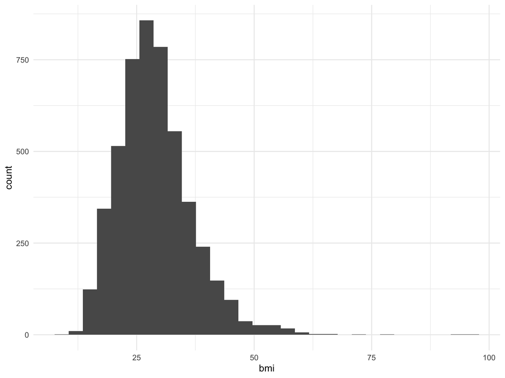

```r
stroke_df_clean %>%
  ggplot(aes(x = bmi)) + geom_histogram()
```

The distribution is right-skewed. Because this is the only variable with missing data (at least the numerical variables) we can impute the `BMI` values with the mean or median.

We found that the stroke outcome distribution is imbalanced with 4861 observations have no stroke while 249 observations have a stroke.

There are 201 missing values in BMI. Among these missing values, 40 observations have a stroke while 161 observations without stroke. We will then apply preprocess imputation in the caret train function to address the imputation problem.

Next, the characteristics of features will help us determine which model would have better prediction accuracy. As the outcome is binary, and the features are mixtures of continuous and categorical variables. We also have to decide how to partition the train and test data, which cross-validation method to use. Evaluation metrics should be used and set up a reasonable tuning grid corresponding to the tuning parameter.

# Models

# Conclusions